# Optimal Treatment Analysis

## Outcome Variable

**Outcome Variable:** whz

## Predictor Variables

**Intervention Variable:** nhh

**Adjustment Set:**

- arm
- W_mage
- meducyrs
- feducyrs
- hhwealth_quart
- W_mhtcm
- W_mwtkg
- W_mbmi
- W_nrooms
- cleanck
- impfloor
- impsan
- safeh20
- delta_W_mage
- delta_meducyrs
- delta_feducyrs
- delta_hhwealth_quart
- delta_W_mhtcm
- delta_W_mwtkg
- delta_W_mbmi
- delta_W_nrooms
- delta_cleanck
- delta_impfloor
- delta_impsan
- delta_safeh20

## Stratifying Variables

The analysis was stratified on these variable(s):

- agecat
- studyid
- country

## Data Summary

| agecat | studyid | country | nhh | n_cell | n |
| --- | --- | --- | --- | --- | --- |
| Birth | IRC | INDIA | 3 or less | 52 | 343 |
| Birth | IRC | INDIA | 4-5 | 131 | 343 |
| Birth | IRC | INDIA | 6-7 | 84 | 343 |
| Birth | IRC | INDIA | 8+ | 76 | 343 |
| Birth | NIH-Birth | BANGLADESH | 3 or less | 104 | 575 |
| Birth | NIH-Birth | BANGLADESH | 4-5 | 244 | 575 |
| Birth | NIH-Birth | BANGLADESH | 6-7 | 130 | 575 |
| Birth | NIH-Birth | BANGLADESH | 8+ | 97 | 575 |
| Birth | NIH-Crypto | BANGLADESH | 3 or less | 103 | 707 |
| Birth | NIH-Crypto | BANGLADESH | 4-5 | 318 | 707 |
| Birth | NIH-Crypto | BANGLADESH | 6-7 | 167 | 707 |
| Birth | NIH-Crypto | BANGLADESH | 8+ | 119 | 707 |
| Birth | PROVIDE | BANGLADESH | 3 or less | 103 | 532 |
| Birth | PROVIDE | BANGLADESH | 4-5 | 249 | 532 |
| Birth | PROVIDE | BANGLADESH | 6-7 | 114 | 532 |
| Birth | PROVIDE | BANGLADESH | 8+ | 66 | 532 |
| 6 months | IRC | INDIA | 3 or less | 57 | 408 |
| 6 months | IRC | INDIA | 4-5 | 157 | 408 |
| 6 months | IRC | INDIA | 6-7 | 107 | 408 |
| 6 months | IRC | INDIA | 8+ | 87 | 408 |
| 6 months | LCNI-5 | MALAWI | 3 or less | 224 | 816 |
| 6 months | LCNI-5 | MALAWI | 4-5 | 340 | 816 |
| 6 months | LCNI-5 | MALAWI | 6-7 | 182 | 816 |
| 6 months | LCNI-5 | MALAWI | 8+ | 70 | 816 |
| 6 months | NIH-Birth | BANGLADESH | 3 or less | 95 | 537 |
| 6 months | NIH-Birth | BANGLADESH | 4-5 | 227 | 537 |
| 6 months | NIH-Birth | BANGLADESH | 6-7 | 128 | 537 |
| 6 months | NIH-Birth | BANGLADESH | 8+ | 87 | 537 |
| 6 months | NIH-Crypto | BANGLADESH | 3 or less | 104 | 715 |
| 6 months | NIH-Crypto | BANGLADESH | 4-5 | 326 | 715 |
| 6 months | NIH-Crypto | BANGLADESH | 6-7 | 170 | 715 |
| 6 months | NIH-Crypto | BANGLADESH | 8+ | 115 | 715 |
| 6 months | PROVIDE | BANGLADESH | 3 or less | 105 | 603 |
| 6 months | PROVIDE | BANGLADESH | 4-5 | 289 | 603 |
| 6 months | PROVIDE | BANGLADESH | 6-7 | 130 | 603 |
| 6 months | PROVIDE | BANGLADESH | 8+ | 79 | 603 |
| 6 months | SAS-FoodSuppl | INDIA | 3 or less | 33 | 380 |
| 6 months | SAS-FoodSuppl | INDIA | 4-5 | 166 | 380 |
| 6 months | SAS-FoodSuppl | INDIA | 6-7 | 115 | 380 |
| 6 months | SAS-FoodSuppl | INDIA | 8+ | 66 | 380 |
| 24 months | IRC | INDIA | 3 or less | 58 | 409 |
| 24 months | IRC | INDIA | 4-5 | 158 | 409 |
| 24 months | IRC | INDIA | 6-7 | 107 | 409 |
| 24 months | IRC | INDIA | 8+ | 86 | 409 |
| 24 months | LCNI-5 | MALAWI | 3 or less | 157 | 558 |
| 24 months | LCNI-5 | MALAWI | 4-5 | 230 | 558 |
| 24 months | LCNI-5 | MALAWI | 6-7 | 123 | 558 |
| 24 months | LCNI-5 | MALAWI | 8+ | 48 | 558 |
| 24 months | NIH-Birth | BANGLADESH | 3 or less | 74 | 428 |
| 24 months | NIH-Birth | BANGLADESH | 4-5 | 184 | 428 |
| 24 months | NIH-Birth | BANGLADESH | 6-7 | 100 | 428 |
| 24 months | NIH-Birth | BANGLADESH | 8+ | 70 | 428 |
| 24 months | NIH-Crypto | BANGLADESH | 3 or less | 69 | 514 |
| 24 months | NIH-Crypto | BANGLADESH | 4-5 | 232 | 514 |
| 24 months | NIH-Crypto | BANGLADESH | 6-7 | 130 | 514 |
| 24 months | NIH-Crypto | BANGLADESH | 8+ | 83 | 514 |
| 24 months | PROVIDE | BANGLADESH | 3 or less | 106 | 579 |
| 24 months | PROVIDE | BANGLADESH | 4-5 | 273 | 579 |
| 24 months | PROVIDE | BANGLADESH | 6-7 | 117 | 579 |
| 24 months | PROVIDE | BANGLADESH | 8+ | 83 | 579 |

The following strata were considered:

- agecat: 24 months, studyid: IRC, country: INDIA
- agecat: 24 months, studyid: LCNI-5, country: MALAWI
- agecat: 24 months, studyid: NIH-Birth, country: BANGLADESH
- agecat: 24 months, studyid: NIH-Crypto, country: BANGLADESH
- agecat: 24 months, studyid: PROVIDE, country: BANGLADESH
- agecat: 6 months, studyid: IRC, country: INDIA
- agecat: 6 months, studyid: LCNI-5, country: MALAWI
- agecat: 6 months, studyid: NIH-Birth, country: BANGLADESH
- agecat: 6 months, studyid: NIH-Crypto, country: BANGLADESH
- agecat: 6 months, studyid: PROVIDE, country: BANGLADESH
- agecat: 6 months, studyid: SAS-FoodSuppl, country: INDIA
- agecat: Birth, studyid: IRC, country: INDIA
- agecat: Birth, studyid: NIH-Birth, country: BANGLADESH
- agecat: Birth, studyid: NIH-Crypto, country: BANGLADESH
- agecat: Birth, studyid: PROVIDE, country: BANGLADESH

## Methods Detail

We’re interested in the causal parameters $E[Y_a]$ for all values of $a \in \mathcal{A}$. These parameters represent the mean outcome if, possibly contrary to fact, we intervened to set all units to have $A=a$. Under the randomization and positivity assumptions, these are identified by the statistical parameters $\psi_a=E_W[E_{Y|A,W}(Y|A=a,W)]$. In addition, we’re interested in the mean of $Y$, $E[Y]$ under no intervention (the observed mean). We will estimate these parameters by using SuperLearner to fit the relevant likelihood factors – $E_{Y|A,W}(Y|A=a,W)$ and $p(A=a|W)$, and then updating our likelihood fit using a joint TMLE.

For unadjusted analyses ($W=\{\}$), initial likelihoods were estimated using Lrnr_glm to estimate the simple $E(Y|A)$ and Lrnr_mean to estimate $p(A)$. For adjusted analyses, a small library containing Lrnr_glmnet, Lrnr_xgboost, and Lrnr_mean was used.

Having estimated these parameters, we will then use the delta method to estimate relative risks and attributable risks relative to a prespecified baseline level of $A$.

# Results Detail

## Results Plots

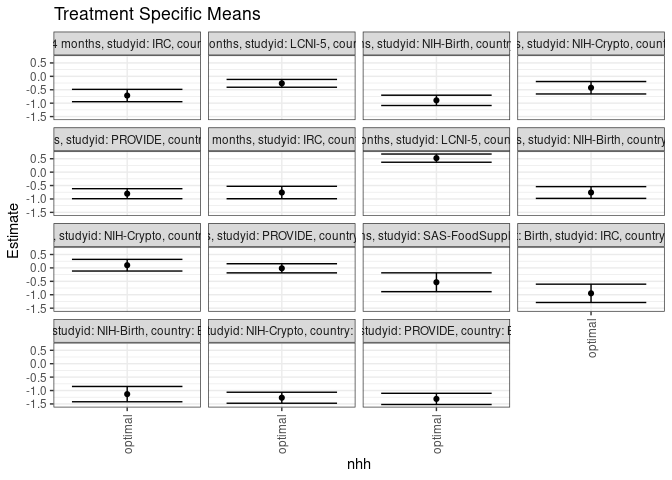

## Results Table

### Parameter: TSM

| agecat | studyid | country | intervention_level | baseline_level | estimate | ci_lower | ci_upper |
| --- | --- | --- | --- | --- | --- | --- | --- |
| Birth | IRC | INDIA | optimal | observed | -0.9475814 | -1.2902307 | -0.6049322 |
| Birth | NIH-Birth | BANGLADESH | optimal | observed | -1.1342578 | -1.4199375 | -0.8485782 |
| Birth | NIH-Crypto | BANGLADESH | optimal | observed | -1.2685582 | -1.4730031 | -1.0641133 |
| Birth | PROVIDE | BANGLADESH | optimal | observed | -1.3125194 | -1.5218820 | -1.1031568 |
| 6 months | IRC | INDIA | optimal | observed | -0.7601163 | -0.9922965 | -0.5279361 |
| 6 months | LCNI-5 | MALAWI | optimal | observed | 0.5223899 | 0.3699558 | 0.6748239 |
| 6 months | NIH-Birth | BANGLADESH | optimal | observed | -0.7602035 | -0.9794125 | -0.5409945 |
| 6 months | NIH-Crypto | BANGLADESH | optimal | observed | 0.1012333 | -0.1161223 | 0.3185890 |
| 6 months | PROVIDE | BANGLADESH | optimal | observed | -0.0138946 | -0.1843052 | 0.1565159 |
| 6 months | SAS-FoodSuppl | INDIA | optimal | observed | -0.5347766 | -0.8858951 | -0.1836581 |
| 24 months | IRC | INDIA | optimal | observed | -0.7153026 | -0.9451467 | -0.4854584 |
| 24 months | LCNI-5 | MALAWI | optimal | observed | -0.2607084 | -0.4054685 | -0.1159483 |
| 24 months | NIH-Birth | BANGLADESH | optimal | observed | -0.8948232 | -1.0866687 | -0.7029776 |
| 24 months | NIH-Crypto | BANGLADESH | optimal | observed | -0.4249031 | -0.6565049 | -0.1933012 |
| 24 months | PROVIDE | BANGLADESH | optimal | observed | -0.8041433 | -0.9908311 | -0.6174556 |

### Parameter: E(Y)

| agecat | studyid | country | intervention_level | baseline_level | estimate | ci_lower | ci_upper |
| --- | --- | --- | --- | --- | --- | --- | --- |
| Birth | IRC | INDIA | observed | observed | -1.0105831 | -1.1973019 | -0.8238643 |
| Birth | NIH-Birth | BANGLADESH | observed | observed | -1.3499217 | -1.4444634 | -1.2553801 |
| Birth | NIH-Crypto | BANGLADESH | observed | observed | -1.2441513 | -1.3281130 | -1.1601897 |
| Birth | PROVIDE | BANGLADESH | observed | observed | -1.2984586 | -1.3752758 | -1.2216415 |
| 6 months | IRC | INDIA | observed | observed | -0.5989297 | -0.7344491 | -0.4634104 |
| 6 months | LCNI-5 | MALAWI | observed | observed | 0.4417647 | 0.3702742 | 0.5132552 |
| 6 months | NIH-Birth | BANGLADESH | observed | observed | -0.4474038 | -0.5378167 | -0.3569909 |
| 6 months | NIH-Crypto | BANGLADESH | observed | observed | 0.0297622 | -0.0491685 | 0.1086930 |
| 6 months | PROVIDE | BANGLADESH | observed | observed | -0.1990907 | -0.2817968 | -0.1163845 |
| 6 months | SAS-FoodSuppl | INDIA | observed | observed | -1.0121579 | -1.1280429 | -0.8962729 |
| 24 months | IRC | INDIA | observed | observed | -0.7458150 | -0.8368180 | -0.6548120 |
| 24 months | LCNI-5 | MALAWI | observed | observed | -0.0477867 | -0.1301103 | 0.0345368 |
| 24 months | NIH-Birth | BANGLADESH | observed | observed | -0.9115790 | -1.0095022 | -0.8136559 |
| 24 months | NIH-Crypto | BANGLADESH | observed | observed | -0.6103502 | -0.7050157 | -0.5156847 |
| 24 months | PROVIDE | BANGLADESH | observed | observed | -0.8928670 | -0.9755153 | -0.8102187 |

### Parameter: PAR

| agecat | studyid | country | intervention_level | baseline_level | estimate | ci_lower | ci_upper |
| --- | --- | --- | --- | --- | --- | --- | --- |
| Birth | IRC | INDIA | optimal | observed | -0.0630016 | -0.3622774 | 0.2362741 |
| Birth | NIH-Birth | BANGLADESH | optimal | observed | -0.2156639 | -0.4762572 | 0.0449294 |
| Birth | NIH-Crypto | BANGLADESH | optimal | observed | 0.0244069 | -0.1619931 | 0.2108068 |
| Birth | PROVIDE | BANGLADESH | optimal | observed | 0.0140608 | -0.1704983 | 0.1986198 |
| 6 months | IRC | INDIA | optimal | observed | 0.1611865 | -0.0466062 | 0.3689793 |
| 6 months | LCNI-5 | MALAWI | optimal | observed | -0.0806252 | -0.2077971 | 0.0465467 |
| 6 months | NIH-Birth | BANGLADESH | optimal | observed | 0.3127997 | 0.1117792 | 0.5138201 |
| 6 months | NIH-Crypto | BANGLADESH | optimal | observed | -0.0714711 | -0.2804724 | 0.1375302 |
| 6 months | PROVIDE | BANGLADESH | optimal | observed | -0.1851960 | -0.3421549 | -0.0282371 |
| 6 months | SAS-FoodSuppl | INDIA | optimal | observed | -0.4773813 | -0.8217520 | -0.1330106 |
| 24 months | IRC | INDIA | optimal | observed | -0.0305124 | -0.2406015 | 0.1795766 |
| 24 months | LCNI-5 | MALAWI | optimal | observed | 0.2129216 | 0.0881770 | 0.3376663 |
| 24 months | NIH-Birth | BANGLADESH | optimal | observed | -0.0167559 | -0.1896235 | 0.1561118 |
| 24 months | NIH-Crypto | BANGLADESH | optimal | observed | -0.1854471 | -0.3860355 | 0.0151412 |
| 24 months | PROVIDE | BANGLADESH | optimal | observed | -0.0887237 | -0.2573910 | 0.0799437 |